# Making interactive ggiraph figures with CMS drug cost data

JM Luther

December 10, 2016

# 1 Purpose

This document is intended to guide you through making a `ggplot2` figure interactive, and then modify a simple custom “tooltip” to augment the figure using the [`ggiraph`](https://github.com/davidgohel/ggiraph) interactive plotting package.

This document assumes you know very little about `CSS` and `html`, because I certainly don’t. It does assume you can do some basic data wrangling and make some simple figures using `ggplot2`. These things won’t be covered here, because there are plenty of details elsewher to help learn these skills, such as:

- The website reference [`ggplot2` website](http://docs.ggplot2.org/current/)
- The reference book [*ggplot2*](https://www.amazon.com/ggplot2-Elegant-Graphics-Data-Analysis/dp/331924275X/ref=dp_ob_title_bk).
- The introductory R online book [R for Data Science](http://r4ds.had.co.nz/). This is the place to start learning R if you need the basics.

## 1.1 The `ggiraph` Package

The `ggiraph` package by [David Gohel](https://twitter.com/davidgohel)) makes ggplot figures interactive, by providing one of three actions to the data:

- `tooltip`: column of dataset that contains tooltips to be displayed when mouse is over elements.
- `onclick`: column of dataset that contains javascript function to be executed when elements are clicked.
- `data_id`: column of dataset that contains id to be associated with elements.

For some nice examples of interactive features made with the ggiraph package, see:

- [this map by Bob Rudis](https://beta.rstudioconnect.com/hrbrmstr/ggiraphe/ggiraphe.html)
- [this Olympic bargraph by Duc Quang Nguyen](http://www.swissinfo.ch/eng/rio-2016-_swiss-olympians---the-solo-specialists-/42349156?utm_content=buffer9f406&utm_medium=social&utm_source=twitter.com&utm_campaign=buffer). Possibly my favorite
- [this time series by Duc Quang Nguyen](http://www.swissinfo.ch/eng/by-the-numbers_a-greying-planet-from-north-to-south/42207298)
- this map by Duc Quang Nguyen
- [this map by Duc Quang Nguyen](http://www.swissinfo.ch/eng/migration-series--part-1-_who-are-the-25--foreign-population-in-switzerland-/42412156?utm_content=bufferd6a4b&utm_medium=social&utm_source=twitter.com&utm_campaign=buffer)

# 2 CMS Drug Price Data

Data can be download as an Excel file (.xlsx) from the [2015 Medicare Drug Spending Data](https://www.cms.gov/Research-Statistics-Data-and-Systems/Statistics-Trends-and-Reports/Information-on-Prescription-Drugs/2015MedicareData.html) and contains drug costs paid by Medicare Part D between 2011-2015. Click on the “Part D data” link to download the .zip folder containing the excel file.

The data is not clean, and a few dataframe tidying steps are needed.

- Import data using the `read_excel` function from the `readxl` package. Need to download just the Data sheet, and avoid the first few lines.
- Variable names are not acceptable and need to be cleaned up
- The data is in wide format, with repeated variables representing the same thing, just different years (e.g., `cost_2011`, `cost_2012`, etc.). This is cleaned up quickly using a few `tidyr` and `dplyr` functions.
- For some reason, CMS just calculated the price change for the year 2015, even though data is there for every year. I’ll calculate for each year.

Load the data for real.

```r
library(tidyverse)
library(stringi)
getwd()
```

```
## [1] "C:/Users/lutherjm/Documents/R Working folder/Shiny Apps/CMS Drug Prices"
```

```r
drugData <- readRDS(file="drugData.rds")

library(ggiraph)
hover_css <- "stroke:orange;stroke-width:3"
#tooltip_css <- "border-radius:10px 10px 10px 10px;"
```

# 3 Simple ggplot

The first basic example will demonstrate the basic time-series plot generated using `ggplot` versus `ggplot + ggiraph`.

There are multiple versions of amlodipine available, which you can see by the multiple trend lines.

- Brand-name (Norvasc). the most expensive.
- Combination formulations (amlodipine/atorvastatin)
- Generic Amlodipine. the cheapest version

## 3.1 ggplot

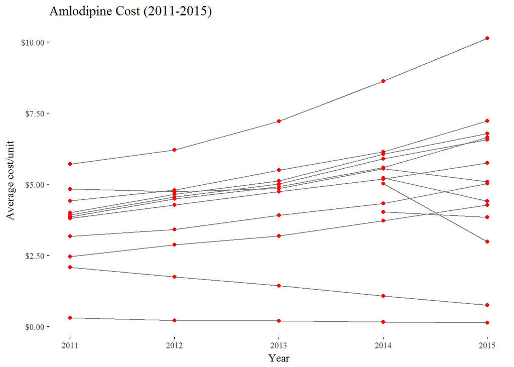

```r
drug <- "Amlodipine"
fig <- drugData[grep(drug, drugData$generic_name, ignore.case = T), ] %>%
  group_by(formulation) %>%
  ggplot(aes(year, average_cost_per_unit, group=formulation)) +
  geom_line(color="grey50") +
  geom_point(color="red") +
  scale_y_continuous(labels=scales::dollar) +
  labs(x="Year", y="Average cost/unit",
       title=paste0(drug, " Cost (2011-2015)")) +
  ggthemes::theme_tufte()
fig
```

## 3.2 +ggiraph

```r
fig <- drugData[grep(drug, drugData$generic_name, ignore.case = T), ] %>%
  group_by(formulation) %>%
  ggplot(aes(year, average_cost_per_unit, group=formulation,
             tooltip=brand_name,
             data_id=formulation)) +
  geom_line_interactive(color="grey50") +
  geom_point_interactive(color="red") +
  scale_y_continuous(labels=scales::dollar) +
  labs(x="Year", y="Average cost/unit",
       title=paste0(stringi::stri_trans_totitle(drug), " Cost (2011-2015)")) +
  ggthemes::theme_tufte()
ggiraph(code = print(fig), width=0.6,  hover_css = hover_css)
```

[interactive chart not shown]

The `hover_css` makes the line or point turn orange when the pointer hovers over the data point.  
The `tooltip=brand_name` makes the data in the `brand_name` variable appear when the pointer hovers over the data. It is not formatted and has no fancy bells or whistles. It would be nice to make it look a little better than this.

# 4 Modify a simple tooltip

More data can be added to the tooltip, by storing this information in a new data column `drugData$tip` to pull into the tooltip text. This will just be plain text of the drug brand name and generic name.

- `paste0` strings the text together, and `/n` creates a line break so drug names will display on separate lines.
- The aesthetic aes(`tooltip=tip`) tells the tooltip to lookup text in the `drugData$tip` column for the information.

```r
drugData$tip <- paste0(drugData$brand_name,"\n",
                       drugData$generic_name)
fig <- drugData[grep(drug, drugData$generic_name, ignore.case = T), ] %>%
  group_by(formulation) %>%
  ggplot(aes(year, average_cost_per_unit, group=formulation,
             tooltip=tip, use_jquery=TRUE,
             data_id=formulation)) +
  geom_line_interactive(color="grey50") +
  geom_point_interactive(color="red") +
  scale_y_continuous(labels=scales::dollar) +
  labs(x="Year", y="Average cost/unit",
       title=paste0(stringi::stri_trans_totitle(drug), " Cost (2011-2015)"),
       subtitle="Cost per unit") +
  ggthemes::theme_tufte()
ggiraph(code = print(fig), width=0.5, hover_css = hover_css)
```

[interactive chart not shown]

# 5 More tooltip modifications

Even more data can be added to the tooltip, and the text format can be improved. This will contain html format text, so it helps to understand some basic html formatting. The `html` contains the content of the webpage. The formatting can be controlled by CSS (Cascading Style Sheets) commands.

There are several ways to control the style of the html page using CSS:

- Link to an external CSS file (style.css)
  - In the rmarkdown header (css: “style.css”)
  - Using `includeCSS(“style.css”)
  - There are other options if creating a Shiny app (include in `www/` folder).
- Write CSS style in the header
- Write CSS in style attribute within html tags

If CSS is included in more than one place, there are rules to determine which rules:  
CSS in an html tag > header CSS style > CSS file

Some other useful html/CSS basics:

- Paragraphs/Lines:
  - require an opening tag (*e.g.*, `<p>`) and closing tag (`</p>`) given around each block:
    - `<strong> The text in between will be controlled by the CSS setting for "strong" (currently {color: gold;}) </strong>`
    - **The text in between will be controlled by the CSS setting for “strong” (currently {color: gold;})**
  - `<p>` paragraph:
  - `<br>` line break:
  - `<hr />` horizontal line: do not need to use line break before this.
- Text format:
  - `<em>` emphasis: usually italic
  - `<strong>` strong: usually bolds
  - `<i>` italic: usually, unless overridden in the .css file.
- Tables:
  - `<table>` start/end table
  - `<tr>` table row
  - `<th>` table header (usually bold, centered)
  - `<td>` table cell detail (usually normal, left-aligned)
  - `<colgroup>`, `<col>`,
    - can control format of cell groups: `<col span="2" style="background-color:red">`

Further resources with CSS details:

1. [w3schools.com](http://www.w3schools.com/css/css_tooltip.asp) which contains introduction, tutorials, and working examples.
2. [w3schools.com HTML tag reference](http://www.w3schools.com/tags/tag_hr.asp)
3. [Mozilla developor network](https://developer.mozilla.org/en-US/docs/Web/Guide/CSS/Getting_Started/What_is_CSS)

Details to create a custom tooltip:

- Will combine html tags (e.g., `<p>`, `<hr />`) with text using the `paste0` command to create the `drugData$tip` field
- While we’re at it, we’ll convert the Drug names to title case using a command from the `stringi` package.
- and add some cost data

```r
drugData$tip <-
  paste0("<p>", stri_trans_totitle(drugData$brand_name),"</p>",
         "<p>(",stri_trans_totitle(drugData$generic_name), ")<p>",
         "<hr />",
         "Unit Cost: $", round(drugData$average_cost_per_unit, 2),"<br>")

fig <- drugData[grep(drug, drugData$generic_name, ignore.case = T), ] %>%
  group_by(formulation) %>%
  ggplot(aes(year, average_cost_per_unit, group=formulation,
             tooltip=tip, use_jquery=TRUE,
             data_id=formulation)) +
  geom_line_interactive(color="grey50") +
  geom_point_interactive(color="red") +
  scale_y_continuous(labels=scales::dollar) +
  labs(x="Year", y="Average cost/unit",
       title=paste0(stringi::stri_trans_totitle(drug), " Cost (2011-2015)"),
       subtitle="Cost per unit") +
  ggthemes::theme_tufte()
ggiraph(code = print(fig), width=0.5, hover_css = hover_css)
```

[interactive chart not shown]

# 6 Extra Tooltip formatting

Some additional formatting can be added to the tooltip from with the `drugData$tip` text field:

```r
drugData$tip <-
  paste0("<h3><strong><span style=\"color: gold\"}>", stri_trans_totitle(drugData$brand_name),"</span></strong><br></h3>",
         "<h4><strong><span style=\"color: gold\"}>(",stri_trans_totitle(drugData$generic_name), ")</span></strong></h4>",
         "<hr />",
         "Total Cost(millions): $", round(drugData$total_spending/1000000, 2),"<br>",
         "Total Cost (%ile): ", round(drugData$pctile_total_cost, 2),  "<br>",
         "Total Cost (Rank): #", drugData$rank_total, " of ", drugData$nDrugs, "<br>",
         "<hr />",
         "Unit Cost: $", round(drugData$average_cost_per_unit, 2),"<br>",
         "Unit Cost (%ile): ", round(drugData$pctile_cost_per_unit, 2), "<br>",
         "Unit Cost (Rank): #", drugData$rank_avg_cost, " of ", drugData$nDrugs, "<br>",
         "Price change($): $", ifelse(is.na(drugData$annual_change_per_unit), "", ifelse(drugData$annual_change_per_unit>0, "+", "")),
         ifelse(is.na(drugData$annual_change_per_unit)," --- ",round(drugData$annual_change_per_unit, 2)),  "<br>",
         "Price change(%): ",ifelse(is.na(drugData$annual_change_per_unit_pct), "", ifelse(drugData$annual_change_per_unit_pct>0, "+", "")),
         ifelse(is.na(drugData$annual_change_per_unit_pct)," --- ",round(drugData$annual_change_per_unit_pct, 2)), "%<br>")
fig <- drugData[grep(drug, drugData$generic_name, ignore.case = T), ] %>%
  group_by(formulation) %>%
  ggplot(aes(year, average_cost_per_unit, group=formulation,
             tooltip=tip, use_jquery=TRUE,
             data_id=formulation)) +
  geom_line_interactive(color="grey50") +
  geom_point_interactive(color="red") +
  scale_y_continuous(labels=scales::dollar) +
  labs(x="Year", y="Average cost/unit",
       title=paste0(stringi::stri_trans_totitle(drug), " Cost (2011-2015)"),
       subtitle="Cost per unit") +
  ggthemes::theme_tufte()
ggiraph(code = print(fig), width=0.5, hover_css = hover_css)
```

[interactive chart not shown]